# CS 422 Section 04 Homework 2

Thomas Ehling A20432671

## Homework 2

### Due Date: Friday, October 12, 2018 11:59:59 PM Chicago Time

## 1 Exercices

### Chapter 4 : q2

### Chapter 4 : q3

### Chapter 4 : q5

## 2 Practiclum Problems

```r
library(rpart)
library(rpart.plot)
library(pROC)
library(caret)
library(randomForest)
library(arules)
library(arulesViz)
library(RColorBrewer)
```

## 2.1 Problem 1

```r
set.seed(1122)
setwd('/home/french_magician/Documents/Chicago/DM/Assigment_2')
rm(list=ls())
options("digits"=3)
df_census <- read.csv("adult-train.csv", sep=",", header=T)
df_census_test <- read.csv("adult-test.csv", sep=",", header=T)
summary(df_census)
```

```
      age                  workclass         fnlwgt               education     education_num
 Min.   :17.0   Private         :22695   Min.   :  12285   HS-grad     :10501   Min.   : 1.0
 1st Qu.:28.0   Self-emp-not-inc: 2541   1st Qu.: 117832   Some-college: 7290   1st Qu.: 9.0
 Median :37.0   Local-gov       : 2093   Median : 178363   Bachelors   : 5355   Median :10.0
 Mean   :38.6   ?               : 1836   Mean   : 189783   Masters     : 1723   Mean   :10.1
 3rd Qu.:48.0   State-gov       : 1298   3rd Qu.: 237054   Assoc-voc   : 1382   3rd Qu.:12.0
 Max.   :90.0   Self-emp-inc    : 1116   Max.   :1484705   11th        : 1175   Max.   :16.0
                (Other)         :  981                     (Other)     : 5134
               marital_status            occupation           relationship                   race
 Divorced             : 4443   Prof-specialty :4140   Husband       :13193   Amer-Indian-Eskimo:  311
 Married-AF-spouse    :   23   Craft-repair   :4099   Not-in-family : 8305   Asian-Pac-Islander: 1039
 Married-civ-spouse   :14976   Exec-managerial:4066   Other-relative:  980   Black             : 3124
 Married-spouse-absent:  418   Adm-clerical   :3770   Own-child     : 5068   Other             :  271
 Never-married        :10682   Sales          :3650   Unmarried     : 3446   White             :27815
 Separated            : 1025   Other-service  :3295   Wife          : 1568
 Widowed              :  993   (Other)        :9540
     sex         capital_gain    capital_loss  hours_per_week       native_country    income
 Female:10770   Min.   :    0   Min.   :   0   Min.   : 1.0   United-States:29170   <=50K:24719
 Male  :21790   1st Qu.:    0   1st Qu.:   0   1st Qu.:40.0   Mexico       :  643   >50K : 7841
                Median :    0   Median :   0   Median :40.0   ?            :  583
                Mean   : 1078   Mean   :  87   Mean   :40.4   Philippines  :  198
                3rd Qu.:    0   3rd Qu.:   0   3rd Qu.:45.0   Germany      :  137
                Max.   :99999   Max.   :4356   Max.   :99.0   Canada       :  121
                                                              (Other)      : 1708
```

### 2.1-A

```r
df_census
```

| age | workclass | fnlwgt | education | education_num | marital_status | occupation | relationship | race | sex | capital_gain | capital_loss | hours_per_week | native_country | income |
| --- | --- | --- | --- | --- | --- | --- | --- | --- | --- | --- | --- | --- | --- | --- |
| 39 | State-gov | 77516 | Bachelors | 13 | Never-married | Adm-clerical | Not-in-family | White | Male | 2174 | 0 | 40 | United-States | <=50K |
| 50 | Self-emp-not-inc | 83311 | Bachelors | 13 | Married-civ-spouse | Exec-managerial | Husband | White | Male | 0 | 0 | 13 | United-States | <=50K |
| 38 | Private | 215646 | HS-grad | 9 | Divorced | Handlers-cleaners | Not-in-family | White | Male | 0 | 0 | 40 | United-States | <=50K |
| 53 | Private | 234721 | 11th | 7 | Married-civ-spouse | Handlers-cleaners | Husband | Black | Male | 0 | 0 | 40 | United-States | <=50K |
| 28 | Private | 338409 | Bachelors | 13 | Married-civ-spouse | Prof-specialty | Wife | Black | Female | 0 | 0 | 40 | Cuba | <=50K |
| 37 | Private | 284582 | Masters | 14 | Married-civ-spouse | Exec-managerial | Wife | White | Female | 0 | 0 | 40 | United-States | <=50K |
| 49 | Private | 160187 | 9th | 5 | Married-spouse-absent | Other-service | Not-in-family | Black | Female | 0 | 0 | 16 | Jamaica | <=50K |
| 52 | Self-emp-not-inc | 209642 | HS-grad | 9 | Married-civ-spouse | Exec-managerial | Husband | White | Male | 0 | 0 | 45 | United-States | >50K |
| 31 | Private | 45781 | Masters | 14 | Never-married | Prof-specialty | Not-in-family | White | Female | 14084 | 0 | 50 | United-States | >50K |
| 42 | Private | 159449 | Bachelors | 13 | Married-civ-spouse | Exec-managerial | Husband | White | Male | 5178 | 0 | 40 | United-States | >50K |

[output cut: 990 more lines]

```r
for (i in 1:ncol(df_census)){
  interrogation_rows <- which(df_census[,i] == '?')
  if (length(interrogation_rows) != 0){
      cat("Removing", length(interrogation_rows), "'?' for the attribute : ", names(df_census)[i], "\n")
      df_census<- df_census[-which(df_census[,i] == '?'), ]
  }
}
```

```
Removing 1836 '?' for the attribute :  workclass
Removing 7 '?' for the attribute :  occupation
Removing 556 '?' for the attribute :  native_country
```

```r
df_census
```

|  | age | workclass | fnlwgt | education | education_num | marital_status | occupation | relationship | race | sex | capital_gain | capital_loss | hours_per_week | native_country | income |
| --- | --- | --- | --- | --- | --- | --- | --- | --- | --- | --- | --- | --- | --- | --- | --- |
| 1 | 39 | State-gov | 77516 | Bachelors | 13 | Never-married | Adm-clerical | Not-in-family | White | Male | 2174 | 0 | 40 | United-States | <=50K |
| 2 | 50 | Self-emp-not-inc | 83311 | Bachelors | 13 | Married-civ-spouse | Exec-managerial | Husband | White | Male | 0 | 0 | 13 | United-States | <=50K |
| 3 | 38 | Private | 215646 | HS-grad | 9 | Divorced | Handlers-cleaners | Not-in-family | White | Male | 0 | 0 | 40 | United-States | <=50K |
| 4 | 53 | Private | 234721 | 11th | 7 | Married-civ-spouse | Handlers-cleaners | Husband | Black | Male | 0 | 0 | 40 | United-States | <=50K |
| 5 | 28 | Private | 338409 | Bachelors | 13 | Married-civ-spouse | Prof-specialty | Wife | Black | Female | 0 | 0 | 40 | Cuba | <=50K |
| 6 | 37 | Private | 284582 | Masters | 14 | Married-civ-spouse | Exec-managerial | Wife | White | Female | 0 | 0 | 40 | United-States | <=50K |
| 7 | 49 | Private | 160187 | 9th | 5 | Married-spouse-absent | Other-service | Not-in-family | Black | Female | 0 | 0 | 16 | Jamaica | <=50K |
| 8 | 52 | Self-emp-not-inc | 209642 | HS-grad | 9 | Married-civ-spouse | Exec-managerial | Husband | White | Male | 0 | 0 | 45 | United-States | >50K |
| 9 | 31 | Private | 45781 | Masters | 14 | Never-married | Prof-specialty | Not-in-family | White | Female | 14084 | 0 | 50 | United-States | >50K |
| 10 | 42 | Private | 159449 | Bachelors | 13 | Married-civ-spouse | Exec-managerial | Husband | White | Male | 5178 | 0 | 40 | United-States | >50K |

[output cut: 990 more lines]

There are 30, 161 rows left, the rows with “?” have been removed.

For the Test data set now :

```r
df_census_test
```

| age | workclass | fnlwgt | education | education_num | marital_status | occupation | relationship | race | sex | capital_gain | capital_loss | hours_per_week | native_country | income |
| --- | --- | --- | --- | --- | --- | --- | --- | --- | --- | --- | --- | --- | --- | --- |
| 25 | Private | 226802 | 11th | 7 | Never-married | Machine-op-inspct | Own-child | Black | Male | 0 | 0 | 40 | United-States | <=50K |
| 38 | Private | 89814 | HS-grad | 9 | Married-civ-spouse | Farming-fishing | Husband | White | Male | 0 | 0 | 50 | United-States | <=50K |
| 28 | Local-gov | 336951 | Assoc-acdm | 12 | Married-civ-spouse | Protective-serv | Husband | White | Male | 0 | 0 | 40 | United-States | >50K |
| 44 | Private | 160323 | Some-college | 10 | Married-civ-spouse | Machine-op-inspct | Husband | Black | Male | 7688 | 0 | 40 | United-States | >50K |
| 18 | ? | 103497 | Some-college | 10 | Never-married | ? | Own-child | White | Female | 0 | 0 | 30 | United-States | <=50K |
| 34 | Private | 198693 | 10th | 6 | Never-married | Other-service | Not-in-family | White | Male | 0 | 0 | 30 | United-States | <=50K |
| 29 | ? | 227026 | HS-grad | 9 | Never-married | ? | Unmarried | Black | Male | 0 | 0 | 40 | United-States | <=50K |
| 63 | Self-emp-not-inc | 104626 | Prof-school | 15 | Married-civ-spouse | Prof-specialty | Husband | White | Male | 3103 | 0 | 32 | United-States | >50K |
| 24 | Private | 369667 | Some-college | 10 | Never-married | Other-service | Unmarried | White | Female | 0 | 0 | 40 | United-States | <=50K |
| 55 | Private | 104996 | 7th-8th | 4 | Married-civ-spouse | Craft-repair | Husband | White | Male | 0 | 0 | 10 | United-States | <=50K |

[output cut: 990 more lines]

```r
for (i in 1:ncol(df_census_test)){
  interrogation_rows <- which(df_census_test[,i] == '?')
  if (length(interrogation_rows) != 0){
      cat("Removing", length(interrogation_rows), "'?' for the attribute : ", names(df_census_test)[i], "\n")
      df_census_test<- df_census_test[-which(df_census_test[,i] == '?'), ]
  }
}
```

```
Removing 963 '?' for the attribute :  workclass
Removing 3 '?' for the attribute :  occupation
Removing 255 '?' for the attribute :  native_country
```

```r
df_census_test
```

|  | age | workclass | fnlwgt | education | education_num | marital_status | occupation | relationship | race | sex | capital_gain | capital_loss | hours_per_week | native_country | income |
| --- | --- | --- | --- | --- | --- | --- | --- | --- | --- | --- | --- | --- | --- | --- | --- |
| 1 | 25 | Private | 226802 | 11th | 7 | Never-married | Machine-op-inspct | Own-child | Black | Male | 0 | 0 | 40 | United-States | <=50K |
| 2 | 38 | Private | 89814 | HS-grad | 9 | Married-civ-spouse | Farming-fishing | Husband | White | Male | 0 | 0 | 50 | United-States | <=50K |
| 3 | 28 | Local-gov | 336951 | Assoc-acdm | 12 | Married-civ-spouse | Protective-serv | Husband | White | Male | 0 | 0 | 40 | United-States | >50K |
| 4 | 44 | Private | 160323 | Some-college | 10 | Married-civ-spouse | Machine-op-inspct | Husband | Black | Male | 7688 | 0 | 40 | United-States | >50K |
| 6 | 34 | Private | 198693 | 10th | 6 | Never-married | Other-service | Not-in-family | White | Male | 0 | 0 | 30 | United-States | <=50K |
| 8 | 63 | Self-emp-not-inc | 104626 | Prof-school | 15 | Married-civ-spouse | Prof-specialty | Husband | White | Male | 3103 | 0 | 32 | United-States | >50K |
| 9 | 24 | Private | 369667 | Some-college | 10 | Never-married | Other-service | Unmarried | White | Female | 0 | 0 | 40 | United-States | <=50K |
| 10 | 55 | Private | 104996 | 7th-8th | 4 | Married-civ-spouse | Craft-repair | Husband | White | Male | 0 | 0 | 10 | United-States | <=50K |
| 11 | 65 | Private | 184454 | HS-grad | 9 | Married-civ-spouse | Machine-op-inspct | Husband | White | Male | 6418 | 0 | 40 | United-States | >50K |
| 12 | 36 | Federal-gov | 212465 | Bachelors | 13 | Married-civ-spouse | Adm-clerical | Husband | White | Male | 0 | 0 | 40 | United-States | <=50K |

[output cut: 990 more lines]

There are 15, 060 rows left, the rows with “?” have been removed.

### 2.1-B-i

```r
str(df_census$income)
```

```
 Factor w/ 2 levels "<=50K",">50K": 1 1 1 1 1 1 1 2 2 2 ...
```

As the attrivute “income” is a factor, the methode used for the tree is “class”.

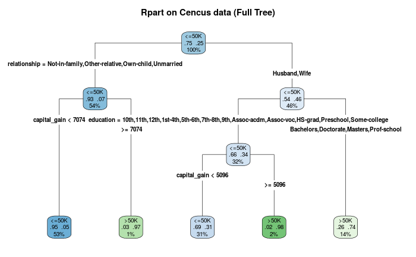

```r
tree <- rpart(income ~ ., data = df_census, method = "class")
rpart.plot(tree, extra=104, fallen.leaves = T, type=4, main="Rpart on Cencus data (Full Tree)")
```

```r
summary(tree)
```

```
Call:
rpart(formula = income ~ ., data = df_census, method = "class")
  n= 30161

      CP nsplit rel error xerror    xstd
1 0.1300      0     1.000  1.000 0.01000
2 0.0642      2     0.740  0.740 0.00897
3 0.0373      3     0.676  0.676 0.00865
4 0.0100      4     0.639  0.639 0.00846

Variable importance
  relationship marital_status   capital_gain      education  education_num            sex     occupation
            24             23             10              9              9              8              7
           age hours_per_week
             5              3

Node number 1: 30161 observations,    complexity param=0.13
  predicted class=<=50K  expected loss=0.249  P(node) =1
    class counts: 22653  7508
   probabilities: 0.751 0.249
  left son=2 (16292 obs) right son=3 (13869 obs)
  Primary splits:
      relationship   splits as  RLLLLR, improve=2280, (0 missing)
      marital_status splits as  LRRLLLL, improve=2240, (0 missing)
      capital_gain   < 5120 to the left,  improve=1540, (0 missing)
      education      splits as  LLLLLLLLLRRLRLRL, improve=1190, (0 missing)
      education_num  < 12.5 to the left,  improve=1190, (0 missing)
  Surrogate splits:
      marital_status splits as  LRRLLLL, agree=0.993, adj=0.984, (0 split)
      sex            splits as  LR, agree=0.691, adj=0.328, (0 split)
      age            < 33.5 to the left,  agree=0.645, adj=0.229, (0 split)
      occupation     splits as  -LLRRRLLLLRRLLR, agree=0.620, adj=0.175, (0 split)
      hours_per_week < 43.5 to the left,  agree=0.604, adj=0.138, (0 split)

Node number 2: 16292 observations,    complexity param=0.0373
  predicted class=<=50K  expected loss=0.0697  P(node) =0.54
    class counts: 15157  1135
   probabilities: 0.930 0.070
  left son=4 (15992 obs) right son=5 (300 obs)
  Primary splits:
```

[output cut: 45 more lines]

```

Node number 7: 4150 observations
  predicted class=>50K   expected loss=0.265  P(node) =0.138
    class counts:  1099  3051
   probabilities: 0.265 0.735

Node number 12: 9219 observations
  predicted class=<=50K  expected loss=0.307  P(node) =0.306
    class counts:  6388  2831
   probabilities: 0.693 0.307

Node number 13: 500 observations
  predicted class=>50K   expected loss=0.018  P(node) =0.0166
    class counts:     9   491
   probabilities: 0.018 0.982
```

The top three important predictors are :

1 ) relationship

2 ) marital_status

3 ) capital_gain

### 2.1-B-ii

The first split is done on the predictor relationship. The predicted class of the first node is “<=50k”. The distribution of observations between the “<=50K” and “>50K” classes at first node is : 0.751 / 0.249, So there are 22653 observations whose income are under 50k and 7508 observations with greater income than 50k.

### 2.1-C

```r
#predict the class for the elementsof the test dataset
predict_class <- predict(tree, newdata = df_census_test, type="class")
#predict the probabilities
predict_prob <- predict(tree, newdata = df_census_test, type="prob")
#creation of a data set with the real values, the predictions and the probabilities.
df_predict <- data.frame(df_census_test$income, predict_class, predict_prob)
colnames(df_predict) <- c("real_values","predictions","inf_or_equal_50k", "sup_50k")
head(df_predict)
```

|  | real_values | predictions | inf_or_equal_50k | sup_50k |
| --- | --- | --- | --- | --- |
| 1 | <=50K | <=50K | 0.947 | 0.0528 |
| 2 | <=50K | <=50K | 0.693 | 0.3071 |
| 3 | >50K | <=50K | 0.693 | 0.3071 |
| 4 | >50K | >50K | 0.018 | 0.9820 |
| 6 | <=50K | <=50K | 0.947 | 0.0528 |
| 8 | >50K | >50K | 0.265 | 0.7352 |

```r
summary(df_predict)
```

```
 real_values   predictions   inf_or_equal_50k    sup_50k
 <=50K:11360   <=50K:12609   Min.   :0.018    Min.   :0.053
 >50K : 3700   >50K : 2451   1st Qu.:0.693    1st Qu.:0.053
                             Median :0.947    Median :0.053
                             Mean   :0.753    Mean   :0.247
                             3rd Qu.:0.947    3rd Qu.:0.307
                             Max.   :0.947    Max.   :0.982
```

Manual calculation of TP, FP, FN and TN (confusion matric=x components) :

```r
df_predict_sup <- df_predict[df_predict$real_values == "<=50K",]
df_predict_inf <- df_predict[df_predict$real_values == ">50K",]
predict_tp <- nrow(df_predict_sup[df_predict_sup$real_values == df_predict_sup$predictions,])
predict_fn <- nrow(df_predict_sup[df_predict_sup$real_values != df_predict_sup$predictions,])
predict_tn <- nrow(df_predict_inf[df_predict_inf$real_values == df_predict_inf$predictions,])
predict_fp <- nrow(df_predict_inf[df_predict_inf$real_values != df_predict_inf$predictions,])
cat(" Check : Total = ", predict_fn+predict_fp+predict_tn+predict_tp, " and there are ", nrow(df_predict), "predictions \n\n")
```

```
 Check : Total =  15060  and there are  15060 predictions
```

```r
cat("TP =", predict_tp, "\n")
```

```
TP = 10772
```

```r
cat("FP =", predict_fp, "\n")
```

```
FP = 1837
```

```r
cat("FN =", predict_fn, "\n")
```

```
FN = 588
```

```r
cat("TN =", predict_tn, "\n")
```

```
TN = 1863
```

There is also the built-in function table to print the confusion matrix :

```r
confusionMatrix(predict_class, as.factor(df_census_test$income))
```

```
Confusion Matrix and Statistics

          Reference
Prediction <=50K  >50K
     <=50K 10772  1837
     >50K    588  1863

               Accuracy : 0.839
                 95% CI : (0.833, 0.845)
    No Information Rate : 0.754
    P-Value [Acc > NIR] : <2e-16

                  Kappa : 0.51
 Mcnemar's Test P-Value : <2e-16

            Sensitivity : 0.948
            Specificity : 0.504
         Pos Pred Value : 0.854
         Neg Pred Value : 0.760
             Prevalence : 0.754
         Detection Rate : 0.715
   Detection Prevalence : 0.837
      Balanced Accuracy : 0.726

       'Positive' Class : <=50K
```

### 2.1-C-i

```r
predict_sensitivity = predict_tp/(predict_tp+predict_fn)
predict_specificity = predict_tn/(predict_tn+predict_fp)
predict_precision = predict_tp/(predict_tp+predict_fp)
cat("TPR =", predict_sensitivity, "\n")
```

```
TPR = 0.948
```

```r
cat("TNR =", predict_specificity, "\n")
```

```
TNR = 0.504
```

```r
cat("PPV =", predict_precision, "\n")
```

```
PPV = 0.854
```

```r
predict_balanced_accuracy = (predict_sensitivity + predict_specificity)/2
cat("balanced accuracy =", predict_balanced_accuracy, "\n")
```

```
balanced accuracy = 0.726
```

The balanced accuracy of this model is 0.726

### 2.1-C-ii

```r
cat("balanced error =", 1-predict_balanced_accuracy, "\n")
```

```
balanced error = 0.274
```

The balanced error rate of this model is 0.274

### 2.1-C-iii

```r
cat("model sensitivity =", predict_sensitivity, "\n")
```

```
model sensitivity = 0.948
```

```r
cat("model specificity =", predict_specificity, "\n")
```

```
model specificity = 0.504
```

The sensitivity of this model is 0.948 The specificity of this model is 0.503

### 2.1-C-iv

```r
predict_false_positive_rate = predict_fp/(predict_tn+predict_fp)
cat("FPR =", predict_false_positive_rate, "\n")
```

```
FPR = 0.496
```

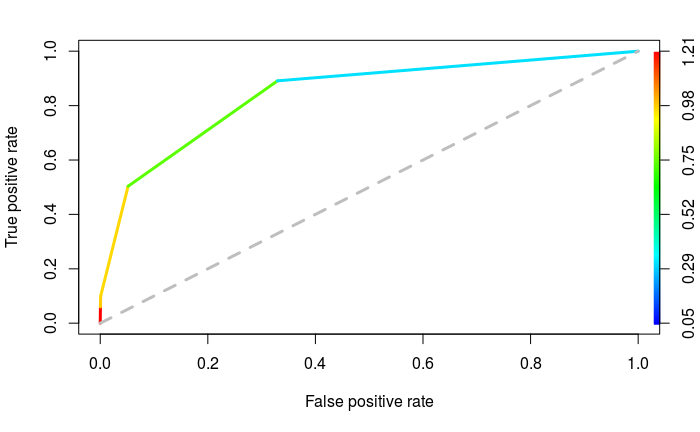

```r
# ROC curve
predict_class.rocr <- predict(tree, newdata=df_census_test, type="prob")[,2]
f.pred <- prediction(predict_class.rocr, df_census_test$income)
f.perf <- performance(f.pred, "tpr", "fpr")
plot(f.perf, colorize=T, lwd=3)
abline(lines(x = c(0,1), y = c(0,1), col="grey", lwd=3, lty=2))
```

```r
auc <- performance(f.pred, measure = "auc")
```

```r
cat(paste("The area under curve (AUC) for this model is ", round(auc@y.values[[1]], 3)))
```

```
The area under curve (AUC) for this model is  0.843
```

### 2.1.D

```r
options("digits"=5)
printcp(tree)
```

```
Classification tree:
rpart(formula = income ~ ., data = df_census, method = "class")

Variables actually used in tree construction:
[1] capital_gain education    relationship

Root node error: 7508/30161 = 0.249

n= 30161

      CP nsplit rel error xerror    xstd
1 0.1300      0     1.000  1.000 0.01000
2 0.0642      2     0.740  0.740 0.00897
3 0.0373      3     0.676  0.676 0.00865
4 0.0100      4     0.639  0.639 0.00846
```

We can notice than the xerror value decrease, but never increase again, so there is no need to prune the tree.

If the Xerror has raised again at some point, we would have pruned the tree at the complexity level of the lowest Xerror value.

### 2.1.E-i

```r
summary(df_census$income)
```

```
<=50K  >50K
22653  7508
```

In the training data_set, there are 22653 observations for <= 50k and 7508 observations for >50k

### 2.1.E-ii

```r
## rows that have "z" and "zz" entries
inf_ind <- which(df_census$income == "<=50K")
sup_ind <- which(df_census$income == ">50K")
nsamp <- min(length(inf_ind), length(sup_ind))
## select `nsamp` entries with "z" and `nsamp` entries with "zz"
pick_inf <- sample(inf_ind, nsamp)
pick_sup <- sample(sup_ind, nsamp)
df_census_even <- df_census[c(pick_inf, pick_sup), ]
df_census_even
```

|  | age | workclass | fnlwgt | education | education_num | marital_status | occupation | relationship | race | sex | capital_gain | capital_loss | hours_per_week | native_country | income |
| --- | --- | --- | --- | --- | --- | --- | --- | --- | --- | --- | --- | --- | --- | --- | --- |
| 10423 | 59 | Federal-gov | 200700 | Assoc-acdm | 12 | Married-civ-spouse | Farming-fishing | Husband | Black | Male | 0 | 0 | 40 | United-States | <=50K |
| 28013 | 19 | Private | 41745 | Some-college | 10 | Never-married | Exec-managerial | Own-child | White | Female | 0 | 0 | 40 | United-States | <=50K |
| 22027 | 25 | Private | 189850 | Some-college | 10 | Never-married | Machine-op-inspct | Own-child | Black | Male | 0 | 0 | 40 | United-States | <=50K |
| 15218 | 24 | Private | 52262 | HS-grad | 9 | Never-married | Machine-op-inspct | Not-in-family | White | Male | 0 | 0 | 40 | United-States | <=50K |
| 14376 | 25 | Federal-gov | 366207 | HS-grad | 9 | Never-married | Transport-moving | Own-child | White | Male | 0 | 0 | 40 | United-States | <=50K |
| 22945 | 54 | Private | 294991 | 10th | 6 | Married-civ-spouse | Handlers-cleaners | Husband | White | Male | 0 | 0 | 40 | United-States | <=50K |
| 26232 | 51 | Private | 215854 | Bachelors | 13 | Divorced | Prof-specialty | Not-in-family | White | Female | 0 | 0 | 50 | United-States | <=50K |
| 18418 | 24 | Private | 117167 | Some-college | 10 | Never-married | Other-service | Not-in-family | White | Female | 0 | 0 | 53 | United-States | <=50K |
| 8330 | 54 | Private | 169182 | HS-grad | 9 | Separated | Adm-clerical | Unmarried | White | Female | 0 | 0 | 38 | Puerto-Rico | <=50K |
| 18062 | 71 | Private | 77253 | HS-grad | 9 | Never-married | Handlers-cleaners | Not-in-family | White | Male | 0 | 0 | 17 | United-States | <=50K |

[output cut: 990 more lines]

We check if the new data set is balanced :

```r
summary(df_census_even$income)
```

```
<=50K  >50K
 7508  7508
```

### 2.1.E-iii

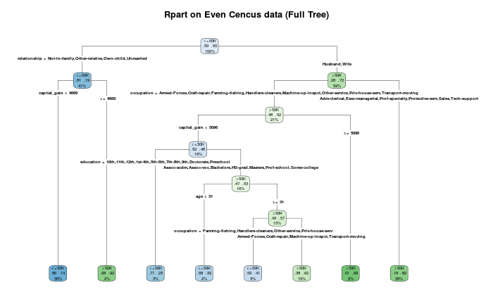

```r
tree_even <- rpart(income ~ ., data = df_census_even, method = "class")
rpart.plot(tree_even, extra=104, fallen.leaves = T, type=4, main="Rpart on Even Cencus data (Full Tree)")
```

```r
summary(tree_even)
```

```
Call:
rpart(formula = income ~ ., data = df_census_even, method = "class")
  n= 15016

        CP nsplit rel error  xerror      xstd
1 0.512520      0   1.00000 1.02144 0.0081587
2 0.039291      1   0.48748 0.48748 0.0070073
3 0.011588      2   0.44819 0.44819 0.0068057
4 0.011454      6   0.39598 0.40770 0.0065751
5 0.010000      7   0.38452 0.39465 0.0064955

Variable importance
  relationship marital_status     occupation            sex            age   capital_gain hours_per_week
            28             28             10             10              8              7              3
     education  education_num
             2              2

Node number 1: 15016 observations,    complexity param=0.51252
  predicted class=<=50K  expected loss=0.5  P(node) =1
    class counts:  7508  7508
   probabilities: 0.500 0.500
  left son=2 (6118 obs) right son=3 (8898 obs)
  Primary splits:
      relationship   splits as  RLLLLR, improve=2042.20, (0 missing)
      marital_status splits as  LRRLLLL, improve=2027.10, (0 missing)
      age            < 29.5   to the left,  improve=1013.90, (0 missing)
      education      splits as  LLLLLLLLLRRLRLRL, improve= 874.52, (0 missing)
      education_num  < 12.5   to the left,  improve= 874.52, (0 missing)
  Surrogate splits:
      marital_status splits as  LRRLLLL, agree=0.994, adj=0.984, (0 split)
      sex            splits as  LR, agree=0.732, adj=0.343, (0 split)
      age            < 29.5   to the left,  agree=0.703, adj=0.271, (0 split)
      occupation     splits as  -LLRRRLRLLRRRRR, agree=0.665, adj=0.178, (0 split)
      hours_per_week < 39.5   to the left,  agree=0.643, adj=0.123, (0 split)

Node number 2: 6118 observations,    complexity param=0.039291
  predicted class=<=50K  expected loss=0.18552  P(node) =0.40743
    class counts:  4983  1135
   probabilities: 0.814 0.186
  left son=4 (5765 obs) right son=5 (353 obs)
```

[output cut: 112 more lines]

```
      relationship   splits as  R----L, agree=0.782, adj=0.050, (0 split)
      sex            splits as  LR, agree=0.782, adj=0.050, (0 split)
      age            < 66.5   to the right, agree=0.777, adj=0.028, (0 split)
      hours_per_week < 31     to the left,  agree=0.776, adj=0.026, (0 split)
      native_country splits as  -RRRRR--RR-RRRL--R-RRRRL-LR-RRRRL-L-RRRRL, agree=0.774, adj=0.015, (0 split)

Node number 102: 464 observations
  predicted class=<=50K  expected loss=0.40733  P(node) =0.0309
    class counts:   275   189
   probabilities: 0.593 0.407

Node number 103: 1558 observations
  predicted class=>50K   expected loss=0.38126  P(node) =0.10376
    class counts:   594   964
   probabilities: 0.381 0.619
```

```r
#predict the class for the elementsof the test dataset
predict_even <- predict(tree_even, newdata = df_census_test, type="class")
confusionMatrix(predict_even, as.factor(df_census_test$income))
```

```
Confusion Matrix and Statistics

          Reference
Prediction <=50K >50K
     <=50K  8879  609
     >50K   2481 3091

               Accuracy : 0.795
                 95% CI : (0.788, 0.801)
    No Information Rate : 0.754
    P-Value [Acc > NIR] : <2e-16

                  Kappa : 0.527
 Mcnemar's Test P-Value : <2e-16

            Sensitivity : 0.782
            Specificity : 0.835
         Pos Pred Value : 0.936
         Neg Pred Value : 0.555
             Prevalence : 0.754
         Detection Rate : 0.590
   Detection Prevalence : 0.630
      Balanced Accuracy : 0.809

       'Positive' Class : <=50K
```

The balanced acuracy is 0.809 The balanced error rate is 0.191 The sensitivity is 0.782 The specificity is 0.835

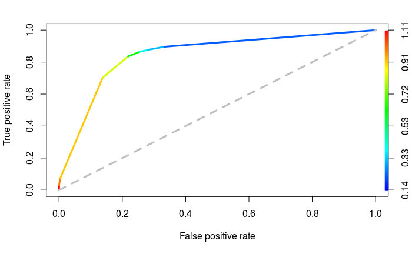

```r
# ROC curve
predict_even.rocr <- predict(tree_even, newdata=df_census_test, type="prob")[,2]
f.pred <- prediction(predict_even.rocr, df_census_test$income)
f.perf <- performance(f.pred, "tpr", "fpr")
plot(f.perf, colorize=T, lwd=3)
abline(lines(x = c(0,1), y = c(0,1), col="grey", lwd=3, lty=2))
```

```r
auc_even <- performance(f.pred, measure = "auc")
```

```r
cat(paste("The area under curve (AUC) for this model is ", round(auc_even@y.values[[1]], 3)))
```

```
The area under curve (AUC) for this model is  0.846
```

### 2.1.F

Comparaison between the 1) Umbalanced model and 2) balanced model

Balanced accuracy : 1) 0.726 | 2) 0.809 : The balanced model is more accurate, it’s good but not sufficent alone.

Balanced error rate : 1) 0.274 | 2) 0.191 : The balanced model has a lower error rate (Normal, it accuracy was better)

Sensitivity : 1) 0.948 | 2) 0.782 : The unbalanced model predict more True Positive that the balanced one.

AUC : 1) 0.843 | 2) 0.846 : The balanced model has a greater area under the ROC curve, it’s great.

With all these results, we can notice that the balanced model is better than the unbalanced one.

## 2.2 Problem 2

```r
set.seed(1122)
```

### 2.2-A-i

```r
rf_tree <- randomForest(income ~ ., data=df_census, importance=TRUE)
```

```r
print(rf_tree)
```

```
Call:
 randomForest(formula = income ~ ., data = df_census, importance = TRUE)
               Type of random forest: classification
                     Number of trees: 500
No. of variables tried at each split: 3

        OOB estimate of  error rate: 13.78%
Confusion matrix:
      <=50K >50K class.error
<=50K 21096 1557    0.068733
>50K   2599 4909    0.346164
```

```r
#predict the class for the elementsof the test dataset
predict_rf <- predict(rf_tree, newdata = df_census_test, type="class")
confusionMatrix(predict_rf, as.factor(df_census_test$income))
```

```
Confusion Matrix and Statistics

          Reference
Prediction <=50K  >50K
     <=50K 10563  1340
     >50K    797  2360

               Accuracy : 0.858
                 95% CI : (0.852, 0.864)
    No Information Rate : 0.754
    P-Value [Acc > NIR] : <2e-16

                  Kappa : 0.597
 Mcnemar's Test P-Value : <2e-16

            Sensitivity : 0.930
            Specificity : 0.638
         Pos Pred Value : 0.887
         Neg Pred Value : 0.748
             Prevalence : 0.754
         Detection Rate : 0.701
   Detection Prevalence : 0.790
      Balanced Accuracy : 0.784

       'Positive' Class : <=50K
```

### 2.2-A-i

The Balanced Accuracy of the model is 0.784

### 2.2-A-ii

The Accuracy of the model is 0.858

### 2.2-A-iii

The Sensitivity of the model is 0.930 The Specificity of the model is 0.638

### 2.2-A-iv

Response class distribution of the model : - <=50k : 11903 - >50k : 3157

### 2.2-A-v

Given the response class distribution, the sensitivity and specificity does make sense. The dtataset is very unbalanced, so it is normal that the response distribution class is unbalanced too. And it makes sense that sensitivity is much higher than specificity since there are much more data with the positive class.

### 2.2-A-vi

Look at important variables

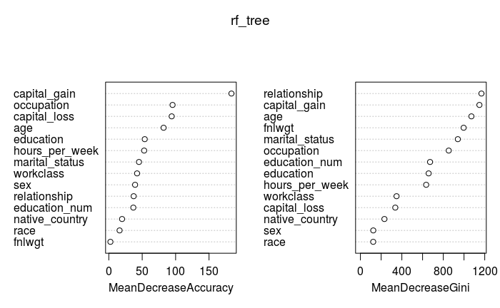

```r
varImpPlot(rf_tree)
```

For the MeanDecreaseAccuracy : - most important variable : capital_gain - least important variable : fnlwgt

For the MeanDecreaseGini : - most important variable : relationship - least important variable : race

### 2.2-A-vii

```r
print(rf_tree)
```

```
Call:
 randomForest(formula = income ~ ., data = df_census, importance = TRUE)
               Type of random forest: classification
                     Number of trees: 500
No. of variables tried at each split: 3

        OOB estimate of  error rate: 13.78%
Confusion matrix:
      <=50K >50K class.error
<=50K 21096 1557    0.068733
>50K   2599 4909    0.346164
```

There are 3 variables tried at each split.

### 2.2-B-i

```
mtry = 3  OOB error = 13.86%
Searching left ...
mtry = 2    OOB error = 13.71%
0.011005 0.01
Searching right ...
mtry = 4    OOB error = 14.14%
-0.03193 0.01
```

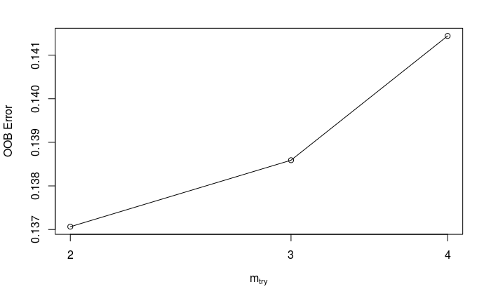

```r
predictors <- df_census
predictors$income <- NULL
mtry <- tuneRF(predictors , df_census$income, ntreeTry=500, stepFactor=1.5,improve=0.01, trace=TRUE, plot=TRUE)
```

### 2.2-B-ii

```r
options("digits"=5)
print(mtry)
```

```
      mtry OOBError
2.OOB    2  0.13706
3.OOB    3  0.13859
4.OOB    4  0.14144
```

```r
options("digits"=3)
```

The optimal value for mtry suggested by the model is 2.

### 2.2-B-iii

```r
rf_tree_opt <- randomForest(income ~ ., data=df_census, importance=TRUE, mtry=2)
```

```r
print(rf_tree_opt)
```

```
Call:
 randomForest(formula = income ~ ., data = df_census, importance = TRUE,      mtry = 2)
               Type of random forest: classification
                     Number of trees: 500
No. of variables tried at each split: 2

        OOB estimate of  error rate: 13.7%
Confusion matrix:
      <=50K >50K class.error
<=50K 21212 1441      0.0636
>50K   2694 4814      0.3588
```

```r
#predict the class for the elementsof the test dataset
predict_rf <- predict(rf_tree_opt, newdata = df_census_test, type="class")
confusionMatrix(predict_rf, as.factor(df_census_test$income))
```

```
Confusion Matrix and Statistics

          Reference
Prediction <=50K  >50K
     <=50K 10617  1358
     >50K    743  2342

               Accuracy : 0.86
                 95% CI : (0.855, 0.866)
    No Information Rate : 0.754
    P-Value [Acc > NIR] : <2e-16

                  Kappa : 0.601
 Mcnemar's Test P-Value : <2e-16

            Sensitivity : 0.935
            Specificity : 0.633
         Pos Pred Value : 0.887
         Neg Pred Value : 0.759
             Prevalence : 0.754
         Detection Rate : 0.705
   Detection Prevalence : 0.795
      Balanced Accuracy : 0.784

       'Positive' Class : <=50K
```

### 2.2-B-iii-(1)

The Balanced Accuracy of the model is 0.784

### 2.2-B-iii-(2)

The Accuracy of the model is 0.860

### 2.2-B-iii-(3)

The Sensitivity of the model is 0.935 The Specificity of the model is 0.633

### 2.2-B-iii-(4)

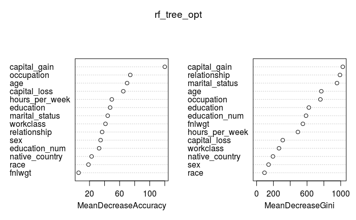

```r
varImpPlot(rf_tree_opt)
```

For the MeanDecreaseAccuracy : - most important variable : capital_gain - least important variable : fnlwgt

For the MeanDecreaseGini : - most important variable : capital_gain - least important variable : race

### 2.2-B-iii-(5)

The Accuracy and Sensitivity of the new model are greater that the last one, where the specificity is lower.

However the Balanced Accuracy is the same.

We can notive from there variations that the new model is slightly more efficient that the last one.

The importance of the variables changed for the MeanDecreaseGini, now the most important variable is capital_gain where it was relationship before.

## 2.3 Association rules

```r
trans <- read.transactions("groceries.csv", sep=",")
summary(trans)
```

```
transactions as itemMatrix in sparse format with
 9835 rows (elements/itemsets/transactions) and
 169 columns (items) and a density of 0.0261

most frequent items:
      whole milk other vegetables       rolls/buns             soda           yogurt          (Other)
            2513             1903             1809             1715             1372            34055

element (itemset/transaction) length distribution:
sizes
   1    2    3    4    5    6    7    8    9   10   11   12   13   14   15   16   17   18   19   20   21
2159 1643 1299 1005  855  645  545  438  350  246  182  117   78   77   55   46   29   14   14    9   11
  22   23   24   26   27   28   29   32
   4    6    1    1    1    1    3    1

   Min. 1st Qu.  Median    Mean 3rd Qu.    Max.
    1.0     2.0     3.0     4.4     6.0    32.0

includes extended item information - examples:
            labels
1 abrasive cleaner
2 artif. sweetener
3   baby cosmetics
```

```r
inspect(trans[1:5])
```

```
    items
[1] {citrus fruit,margarine,ready soups,semi-finished bread}
[2] {coffee,tropical fruit,yogurt}
[3] {whole milk}
[4] {cream cheese,meat spreads,pip fruit,yogurt}
[5] {condensed milk,long life bakery product,other vegetables,whole milk}
```

### 2.3-i

```r
rules <- apriori(trans)
```

```
Apriori

Parameter specification:
 confidence minval smax arem  aval originalSupport maxtime support minlen maxlen target   ext
        0.8    0.1    1 none FALSE            TRUE       5     0.1      1     10  rules FALSE

Algorithmic control:
 filter tree heap memopt load sort verbose
    0.1 TRUE TRUE  FALSE TRUE    2    TRUE

Absolute minimum support count: 983

set item appearances ...[0 item(s)] done [0.00s].
set transactions ...[169 item(s), 9835 transaction(s)] done [0.00s].
sorting and recoding items ... [8 item(s)] done [0.00s].
creating transaction tree ... done [0.00s].
checking subsets of size 1 2 done [0.00s].
writing ... [0 rule(s)] done [0.00s].
creating S4 object  ... done [0.00s].
```

```r
rm(rules)
```

We obtain no rules at all.

### 2.3-ii

```r
rules <- apriori(trans, parameter = list(support=0.001))
```

```
Apriori

Parameter specification:
 confidence minval smax arem  aval originalSupport maxtime support minlen maxlen target   ext
        0.8    0.1    1 none FALSE            TRUE       5   0.001      1     10  rules FALSE

Algorithmic control:
 filter tree heap memopt load sort verbose
    0.1 TRUE TRUE  FALSE TRUE    2    TRUE

Absolute minimum support count: 9

set item appearances ...[0 item(s)] done [0.00s].
set transactions ...[169 item(s), 9835 transaction(s)] done [0.00s].
sorting and recoding items ... [157 item(s)] done [0.00s].
creating transaction tree ... done [0.01s].
checking subsets of size 1 2 3 4 5 6 done [0.02s].
writing ... [410 rule(s)] done [0.00s].
creating S4 object  ... done [0.01s].
```

We got more that 400 rules for a support value of 0.001.

### 2.3-iii

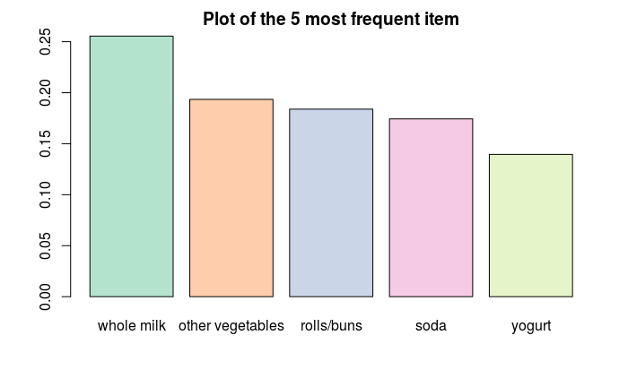

```r
trans_dec = sort(itemFrequency(trans), decreasing=TRUE)
barplot(head(trans_dec, 5),col=brewer.pal(8,'Pastel2'), main="Plot of the 5 most frequent item")
```

The most frequent item is Whole Milk.

### 2.3-iv

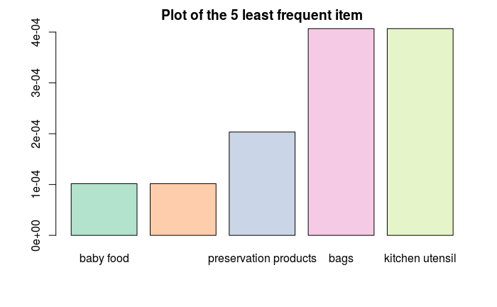

```r
trans_dec = sort(itemFrequency(trans), decreasing=FALSE)
barplot(head(trans_dec, 5),col=brewer.pal(8,'Pastel2'), main="Plot of the 5 least frequent item")
```

The least frequent item is baby food.

### 2.3-v

The top 5 rules, sorted by support are :

```r
inspect(head(n=5, rules, by="support"))
```

```
    lhs                                                         rhs                support confidence lift count
[1] {citrus fruit,root vegetables,tropical fruit,whole milk} => {other vegetables} 0.00315 0.886      4.58 31
[2] {curd,domestic eggs,other vegetables}                    => {whole milk}       0.00285 0.824      3.22 28
[3] {curd,hamburger meat}                                    => {whole milk}       0.00254 0.806      3.16 25
[4] {herbs,rolls/buns}                                       => {whole milk}       0.00244 0.800      3.13 24
[5] {herbs,tropical fruit}                                   => {whole milk}       0.00234 0.821      3.21 23
```

### 2.3-vi

The top 5 rules, sorted by confidence are :

```r
inspect(head(n=5, rules, by="confidence"))
```

```
    lhs                                           rhs          support confidence lift count
[1] {rice,sugar}                               => {whole milk} 0.00122 1          3.91 12
[2] {canned fish,hygiene articles}             => {whole milk} 0.00112 1          3.91 11
[3] {butter,rice,root vegetables}              => {whole milk} 0.00102 1          3.91 10
[4] {flour,root vegetables,whipped/sour cream} => {whole milk} 0.00173 1          3.91 17
[5] {butter,domestic eggs,soft cheese}         => {whole milk} 0.00102 1          3.91 10
```

### 2.3-vii

The bottom 5 rules, sorted by support are :

```r
inspect(tail(n=5, rules, by="support"))
```

```
    lhs                                                                          rhs                support confidence lift count
[1] {oil,other vegetables,tropical fruit,whole milk,yogurt}                   => {root vegetables}  0.00102 0.909      8.34 10
[2] {butter,domestic eggs,other vegetables,tropical fruit,yogurt}             => {whole milk}       0.00102 0.909      3.56 10
[3] {butter,domestic eggs,tropical fruit,whole milk,yogurt}                   => {other vegetables} 0.00102 0.833      4.31 10
[4] {citrus fruit,other vegetables,root vegetables,whipped/sour cream,yogurt} => {whole milk}       0.00102 0.833      3.26 10
[5] {citrus fruit,root vegetables,whipped/sour cream,whole milk,yogurt}       => {other vegetables} 0.00102 0.909      4.70 10
```

### 2.3-viii

```r
inspect(tail(n=5, rules, by="confidence"))
```

```
    lhs                                                               rhs                support confidence lift count
[1] {pip fruit,tropical fruit,whipped/sour cream,whole milk}       => {other vegetables} 0.00163 0.8        4.13 16
[2] {citrus fruit,other vegetables,sausage,whipped/sour cream}     => {whole milk}       0.00122 0.8        3.13 12
[3] {citrus fruit,sausage,whipped/sour cream,whole milk}           => {other vegetables} 0.00122 0.8        4.13 12
[4] {citrus fruit,tropical fruit,whipped/sour cream,yogurt}        => {whole milk}       0.00122 0.8        3.13 12
[5] {rolls/buns,root vegetables,tropical fruit,whipped/sour cream} => {other vegetables} 0.00122 0.8        4.13 12
```